# Hands_on_I_HOMEWORK

Denis Expósito Navarro

Last update: 05 February, 2023

# Analysis of the Heart Disease Dataset

Load the data from [here](https://raw.githubusercontent.com/jpinero/DMI_2021/main/datasets/heart_disease_dataset.csv), and the description is [here](https://raw.githubusercontent.com/jpinero/DMI_2021/main/datasets/heart_disease_description.txt). The original dataset comes from [here](https://archive.ics.uci.edu/ml/datasets/Heart+Disease) and corresponds to the [processed cleveland data](https://archive.ics.uci.edu/ml/machine-learning-databases/heart-disease/processed.cleveland.data)

## Perform an EDA on the dataset

```
##    age sex cp trestbps chol fbs restecg thalach exang oldpeak slope ca thal num
## 1   63   1  1      145  233   1       2     150     0     2.3     3  0    6   0
## 2   67   1  4      160  286   0       2     108     1     1.5     2  3    3   2
## 3   67   1  4      120  229   0       2     129     1     2.6     2  2    7   1
## 4   37   1  3      130  250   0       0     187     0     3.5     3  0    3   0
## 5   41   0  2      130  204   0       2     172     0     1.4     1  0    3   0
## 6   56   1  2      120  236   0       0     178     0     0.8     1  0    3   0
## 7   62   0  4      140  268   0       2     160     0     3.6     3  2    3   3
## 8   57   0  4      120  354   0       0     163     1     0.6     1  0    3   0
## 9   63   1  4      130  254   0       2     147     0     1.4     2  1    7   2
## 10  53   1  4      140  203   1       2     155     1     3.1     3  0    7   1
## 11  57   1  4      140  192   0       0     148     0     0.4     2  0    6   0
## 12  56   0  2      140  294   0       2     153     0     1.3     2  0    3   0
##    patient_id
## 1           1
## 2           2
## 3           3
## 4           4
## 5           5
## 6           6
## 7           7
## 8           8
## 9           9
## 10         10
## 11         11
## 12         12
```

```
##     age sex cp trestbps chol fbs restecg thalach exang oldpeak slope ca thal
## 292  55   0  2      132  342   0       0     166     0     1.2     1  0    3
## 293  44   1  4      120  169   0       0     144     1     2.8     3  0    6
## 294  63   1  4      140  187   0       2     144     1     4.0     1  2    7
## 295  63   0  4      124  197   0       0     136     1     0.0     2  0    3
## 296  41   1  2      120  157   0       0     182     0     0.0     1  0    3
## 297  59   1  4      164  176   1       2      90     0     1.0     2  2    6
## 298  57   0  4      140  241   0       0     123     1     0.2     2  0    7
## 299  45   1  1      110  264   0       0     132     0     1.2     2  0    7
## 300  68   1  4      144  193   1       0     141     0     3.4     2  2    7
## 301  57   1  4      130  131   0       0     115     1     1.2     2  1    7
## 302  57   0  2      130  236   0       2     174     0     0.0     2  1    3
## 303  38   1  3      138  175   0       0     173     0     0.0     1  ?    3
##     num patient_id
## 292   0        292
## 293   2        293
## 294   2        294
## 295   1        295
## 296   0        296
## 297   3        297
## 298   1        298
## 299   1        299
## 300   2        300
## 301   3        301
## 302   1        302
## 303   0        303
```

```
## 'data.frame':    303 obs. of  15 variables:
##  $ age       : int  63 67 67 37 41 56 62 57 63 53 ...
##  $ sex       : int  1 1 1 1 0 1 0 0 1 1 ...
##  $ cp        : int  1 4 4 3 2 2 4 4 4 4 ...
##  $ trestbps  : int  145 160 120 130 130 120 140 120 130 140 ...
##  $ chol      : int  233 286 229 250 204 236 268 354 254 203 ...
##  $ fbs       : int  1 0 0 0 0 0 0 0 0 1 ...
##  $ restecg   : int  2 2 2 0 2 0 2 0 2 2 ...
##  $ thalach   : int  150 108 129 187 172 178 160 163 147 155 ...
##  $ exang     : int  0 1 1 0 0 0 0 1 0 1 ...
##  $ oldpeak   : num  2.3 1.5 2.6 3.5 1.4 0.8 3.6 0.6 1.4 3.1 ...
##  $ slope     : int  3 2 2 3 1 1 3 1 2 3 ...
##  $ ca        : chr  "0" "3" "2" "0" ...
##  $ thal      : chr  "6" "3" "7" "3" ...
##  $ num       : int  0 2 1 0 0 0 3 0 2 1 ...
##  $ patient_id: int  1 2 3 4 5 6 7 8 9 10 ...
```

```
##     age sex cp trestbps chol fbs restecg thalach exang oldpeak slope   ca thal
## 88   53   0  3      128  216   0       2     115     0     0.0     1    0 <NA>
## 167  52   1  3      138  223   0       0     169     0     0.0     1 <NA>    3
## 193  43   1  4      132  247   1       2     143     1     0.1     2 <NA>    7
## 267  52   1  4      128  204   1       0     156     1     1.0     2    0 <NA>
## 288  58   1  2      125  220   0       0     144     0     0.4     2 <NA>    7
## 303  38   1  3      138  175   0       0     173     0     0.0     1 <NA>    3
##     num patient_id
## 88    0         88
## 167   0        167
## 193   1        193
## 267   2        267
## 288   0        288
## 303   0        303
```

```
## 'data.frame':    303 obs. of  15 variables:
##  $ age       : int  63 67 67 37 41 56 62 57 63 53 ...
##  $ sex       : int  1 1 1 1 0 1 0 0 1 1 ...
##  $ cp        : int  1 4 4 3 2 2 4 4 4 4 ...
##  $ trestbps  : int  145 160 120 130 130 120 140 120 130 140 ...
##  $ chol      : int  233 286 229 250 204 236 268 354 254 203 ...
##  $ fbs       : int  1 0 0 0 0 0 0 0 0 1 ...
##  $ restecg   : int  2 2 2 0 2 0 2 0 2 2 ...
##  $ thalach   : int  150 108 129 187 172 178 160 163 147 155 ...
##  $ exang     : int  0 1 1 0 0 0 0 1 0 1 ...
##  $ oldpeak   : num  2.3 1.5 2.6 3.5 1.4 0.8 3.6 0.6 1.4 3.1 ...
##  $ slope     : int  3 2 2 3 1 1 3 1 2 3 ...
##  $ ca        : chr  "0" "3" "2" "0" ...
##  $ thal      : chr  "6" "3" "7" "3" ...
##  $ num       : num  0 1 1 0 0 0 1 0 1 1 ...
##  $ patient_id: int  1 2 3 4 5 6 7 8 9 10 ...
```

```
## 'data.frame':    303 obs. of  15 variables:
##  $ age       : int  63 67 67 37 41 56 62 57 63 53 ...
##  $ sex       : Factor w/ 2 levels "0","1": 2 2 2 2 1 2 1 1 2 2 ...
##  $ cp        : Factor w/ 4 levels "1","2","3","4": 1 4 4 3 2 2 4 4 4 4 ...
##  $ trestbps  : int  145 160 120 130 130 120 140 120 130 140 ...
##  $ chol      : int  233 286 229 250 204 236 268 354 254 203 ...
##  $ fbs       : Factor w/ 2 levels "0","1": 2 1 1 1 1 1 1 1 1 2 ...
##  $ restecg   : Factor w/ 3 levels "0","1","2": 3 3 3 1 3 1 3 1 3 3 ...
##  $ thalach   : int  150 108 129 187 172 178 160 163 147 155 ...
##  $ exang     : Factor w/ 2 levels "0","1": 1 2 2 1 1 1 1 2 1 2 ...
##  $ oldpeak   : num  2.3 1.5 2.6 3.5 1.4 0.8 3.6 0.6 1.4 3.1 ...
##  $ slope     : Factor w/ 3 levels "1","2","3": 3 2 2 3 1 1 3 1 2 3 ...
##  $ ca        : Factor w/ 4 levels "0","1","2","3": 1 4 3 1 1 1 3 1 2 1 ...
##  $ thal      : Factor w/ 3 levels "3","6","7": 2 1 3 1 1 1 1 1 3 3 ...
##  $ num       : Factor w/ 2 levels "0","1": 1 2 2 1 1 1 2 1 2 2 ...
##  $ patient_id: Factor w/ 303 levels "1","2","3","4",..: 1 2 3 4 5 6 7 8 9 10 ...
```

```
## 'data.frame':    303 obs. of  15 variables:
##  $ age       : int  63 67 67 37 41 56 62 57 63 53 ...
##  $ sex       : Factor w/ 2 levels "female","male": 2 2 2 2 1 2 1 1 2 2 ...
##  $ cp        : Factor w/ 4 levels "typical angina",..: 1 4 4 3 2 2 4 4 4 4 ...
##  $ trestbps  : int  145 160 120 130 130 120 140 120 130 140 ...
##  $ chol      : int  233 286 229 250 204 236 268 354 254 203 ...
##  $ fbs       : Factor w/ 2 levels "false","true": 2 1 1 1 1 1 1 1 1 2 ...
##  $ restecg   : Factor w/ 3 levels "normal","stt",..: 3 3 3 1 3 1 3 1 3 3 ...
##  $ thalach   : int  150 108 129 187 172 178 160 163 147 155 ...
##  $ exang     : Factor w/ 2 levels "no","yes": 1 2 2 1 1 1 1 2 1 2 ...
##  $ oldpeak   : num  2.3 1.5 2.6 3.5 1.4 0.8 3.6 0.6 1.4 3.1 ...
##  $ slope     : Factor w/ 3 levels "upsloping","flat",..: 3 2 2 3 1 1 3 1 2 3 ...
##  $ ca        : Factor w/ 4 levels "0","1","2","3": 1 4 3 1 1 1 3 1 2 1 ...
##  $ thal      : Factor w/ 3 levels "normal","fixed defect",..: 2 1 3 1 1 1 1 1 3 3 ...
##  $ num       : Factor w/ 2 levels "no disease","disease": 1 2 2 1 1 1 2 1 2 2 ...
##  $ patient_id: Factor w/ 303 levels "1","2","3","4",..: 1 2 3 4 5 6 7 8 9 10 ...
```

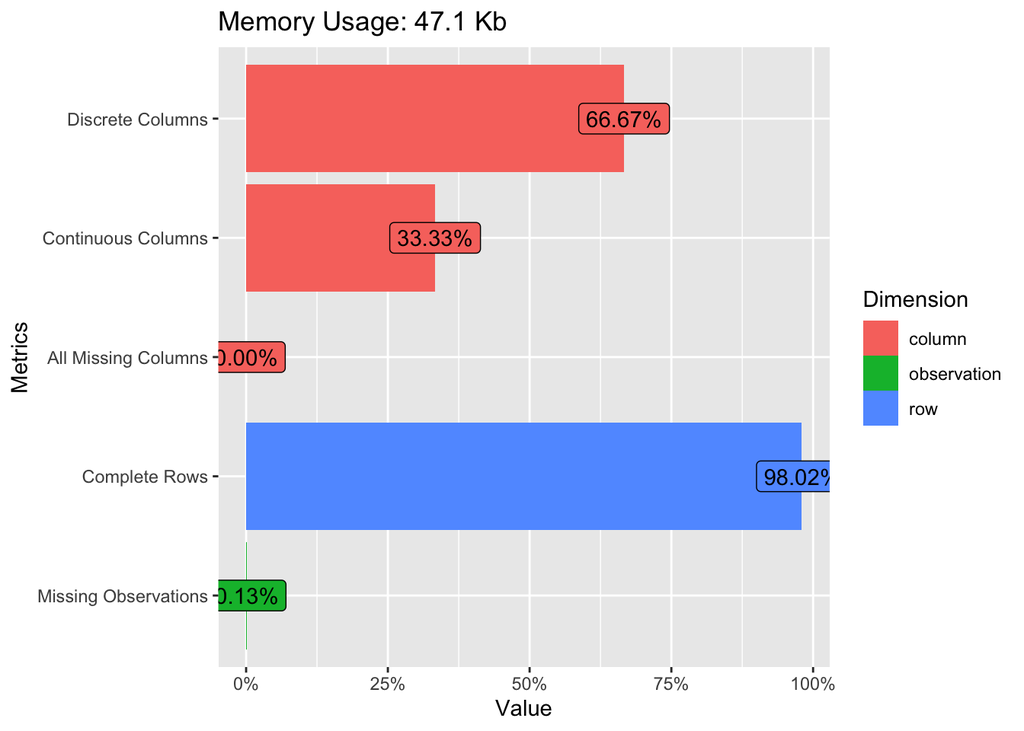

- Most of the variables are discrete (~67%) and missing data is really low (only couple of observations in ca and thal columns), so all columns are informative.

## Create visualizations in order to show which variables seem to be more associated with heart disease

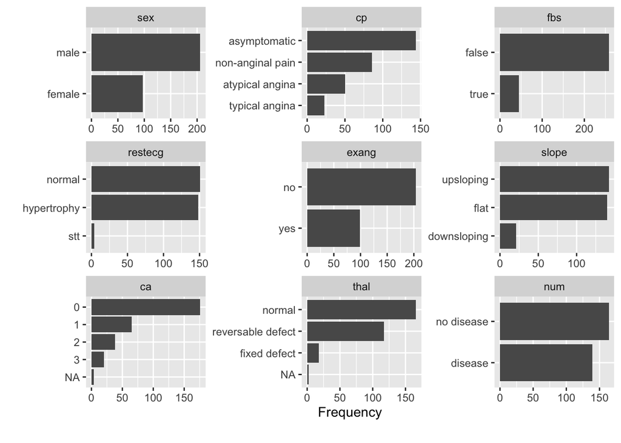

A brief view of the 9 categorical plots: - The number of male patients is double the number of female patients. Majority of patients had asymptomatic chest pain, fasting blood sugar under 120 mg/dl,did not have exercise induced angina, had 0 major vessels colored by fluoroscopy, had normal thal (heart rate). There was equal number of patients with up-sloping and flat peak exercise ST segment.

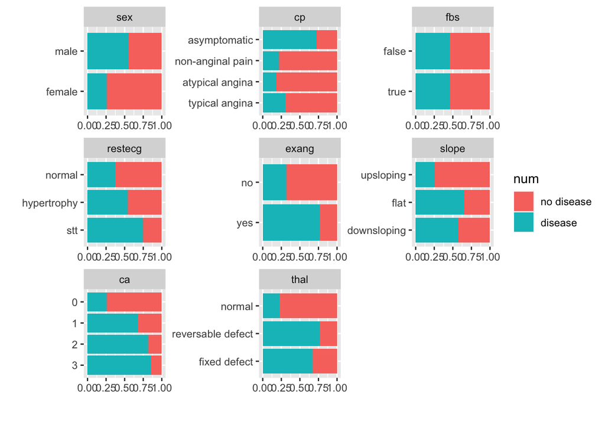

- Disease frequency is doubled in males, specially linked to asymptomatic chest pain. The fasting blood sugar content is practically the same in both conditions and the disease frequency increases gradually with abnormal resting electro-cardiographic results and with the number of major vessels. Disease frequency is also more common with exercise induced angina, flat and down-sloping slope of peak exercise ST segment, rather than up-sloping, and with defects in the heart rate.

```
## [1] "sex : 2.66671234818094e-06"
## [1] "cp : 1.25171060078375e-17"
## [1] "fbs : 0.781273406706378"
## [1] "restecg : 0.00656652381421735"
## [1] "exang : 1.41378809671808e-13"
## [1] "slope : 1.1428845467527e-10"
## [1] "ca : 1.71995176969134e-15"
## [1] "thal : 8.20182028605638e-19"
## [1] "num : 5.47893931881214e-67"
## [1] "patient_id : 0.472985270351046"
```

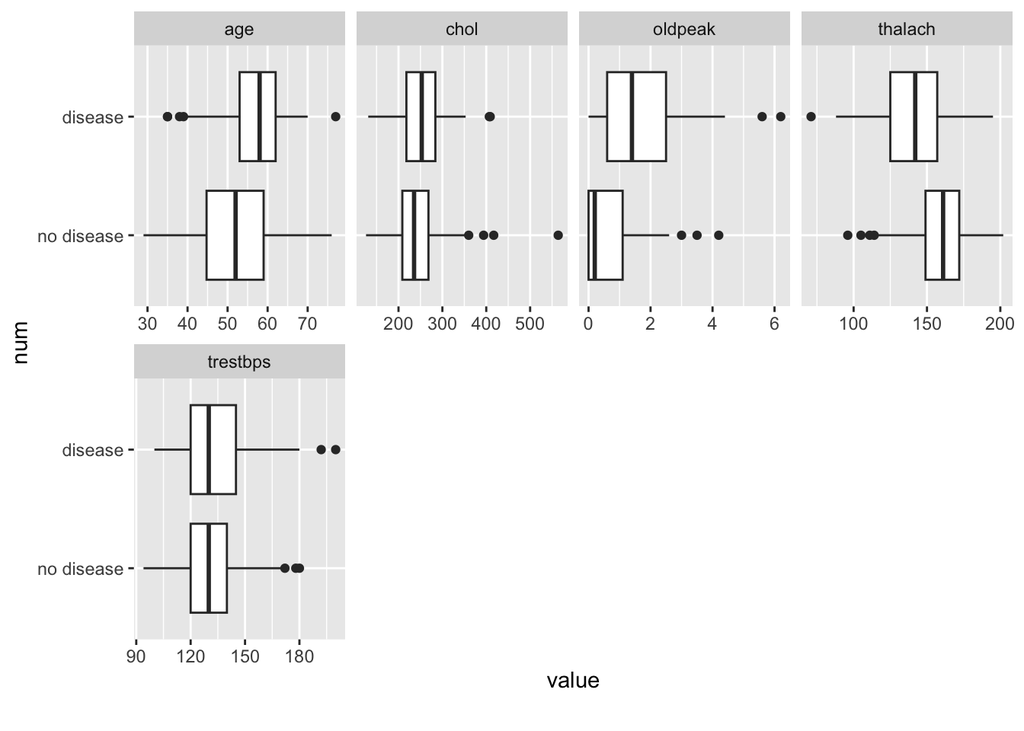

- Disease status of > 50% diameter narrowing is more present in older patients with slightly higher cholesterol level, higher ST depression and lower thalach.

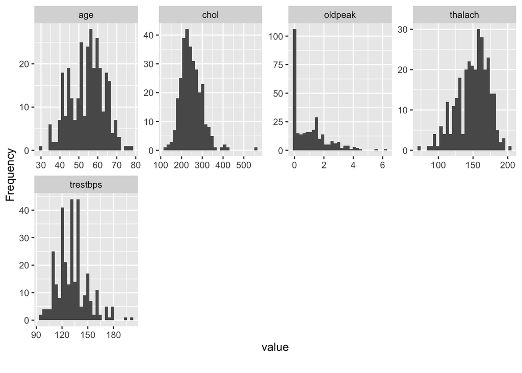

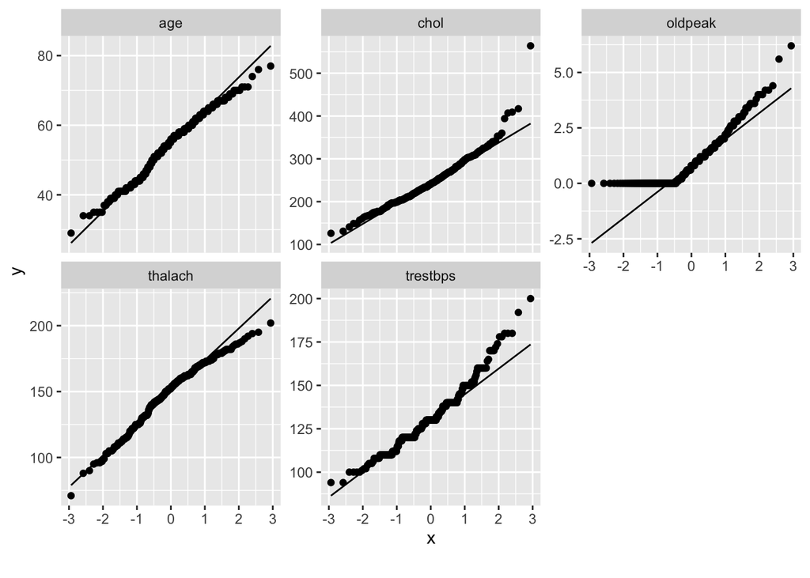

- Plots showing the deviation from the probability distribution (by default normal). Diagonal represents the expected values. Some variables have higher than expected probability (cholesterol, ST depression and resting blood pressure) while the others have lower than expected probability (age, thalach).

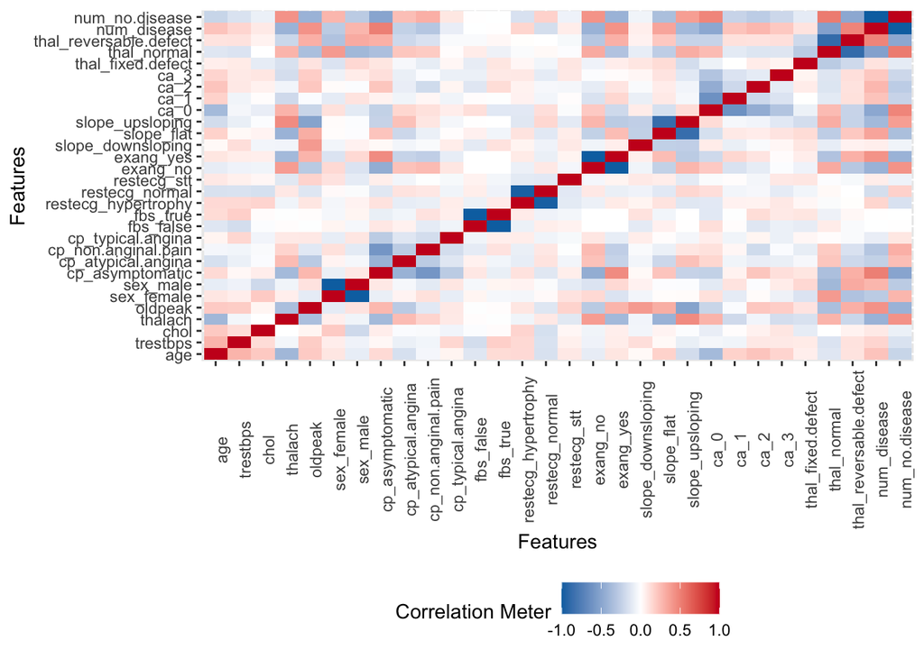

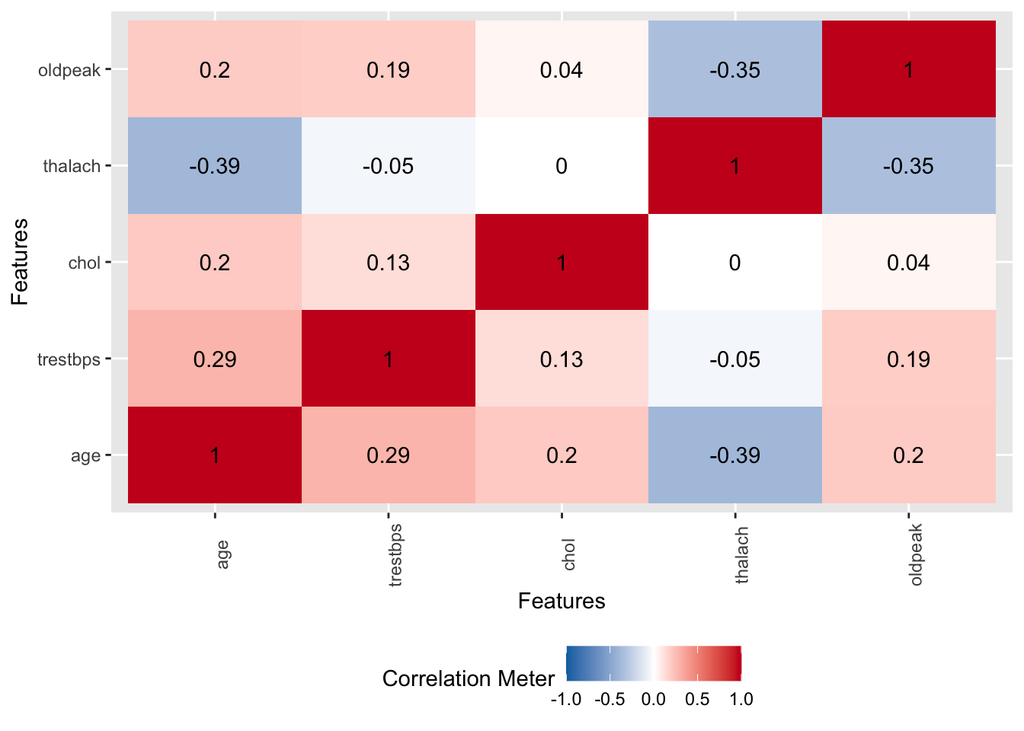

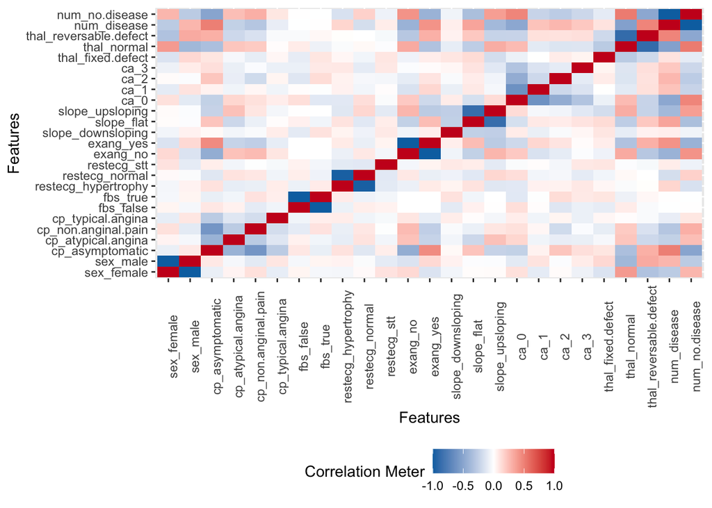

# 2 Difference in mortality rates in hospitalized COVID-19 patients

Using the supplementary material from the [Difference in mortality rates in hospitalized COVID-19 patients identified by cytokine profile clustering using a machine learning approach: An outcome prediction alternative](https://www.frontiersin.org/articles/10.3389/fmed.2022.987182/full), perform the following tasks

## Reproduce Figure 1 from the publication

```
## [1] TRUE
```

```
## [1] TRUE
```

```
## tibble [215 × 18] (S3: tbl_df/tbl/data.frame)
##  $ ...1                                   : chr [1:215] "ID" "COAG-HSJD-001" "COAG-HSJD-002" "COAG-HSJD-003" ...
##  $ Demographic data                       : chr [1:215] "Age" "63" "52" "74" ...
##  $ ...3                                   : chr [1:215] "Gender" "F" "M" "M" ...
##  $ ...4                                   : chr [1:215] "BMI" "NI" "NI" "25.8" ...
##  $ General Information                    : chr [1:215] "Syntoms onset" "44040" "44041" "NI" ...
##  $ ...6                                   : chr [1:215] "Hospitalization date" "44047" "44045" "44024" ...
##  $ Clinical characteristics and management: chr [1:215] "Admission to ICU" "No" "No" "Yes" ...
##  $ ...8                                   : chr [1:215] "Days in ICU" "0" "0" "10" ...
##  $ ...9                                   : chr [1:215] "ARDS Diagnosis" "No" "Yes" "Yes" ...
##  $ ...10                                  : chr [1:215] "Days with ARDS" "0" "4" "10" ...
##  $ ...11                                  : chr [1:215] "CRS Diagnosis" "No" "No" "Yes" ...
##  $ ...12                                  : chr [1:215] "Days with CRS" "0" "0" "10" ...
##  $ ...13                                  : chr [1:215] "Use of NIV" "No" "Yes" "No" ...
##  $ ...14                                  : chr [1:215] "Days with NIV" "0" "5" "0" ...
##  $ ...15                                  : chr [1:215] "Use of AMV" "No" "No" "Yes" ...
##  $ ...16                                  : chr [1:215] "Days with AMV" "0" "0" "10" ...
##  $ ...17                                  : chr [1:215] "Days of hospitalization" "8" "5" "10" ...
##  $ ...18                                  : chr [1:215] "Death" "No" "No" "Yes" ...
```

```
## tibble [446 × 27] (S3: tbl_df/tbl/data.frame)
##  $ ID                                 : chr [1:446] NA "COAG-HSJD-001" "COAG-HSJD-002" "COAG-HSJD-003" ...
##  $ ...2                               : chr [1:446] "Day" "1" "1" "1" ...
##  $ Laboratoy and Cytokine Measurements: chr [1:446] "IL-1β" "0" "0" "0" ...
##  $ ...4                               : chr [1:446] "IL-6" "4.5999999999999996" "0.5" "147.69999999999999" ...
##  $ ...5                               : chr [1:446] "IL-10" "4.0599999999999996" "9.16" "4.7" ...
##  $ ...6                               : chr [1:446] "IFN-ɑ" "2.69" "2.52" "0.4" ...
##  $ ...7                               : chr [1:446] "TNF-ɑ" "0.72" "1.4" "0" ...
##  $ ...8                               : chr [1:446] "IL-8" "37.619999999999997" "8.66" "133.52510000000001" ...
##  $ ...9                               : chr [1:446] "G-CSF" "3.7" "2.52" "10.344060000000001" ...
##  $ ...10                              : chr [1:446] "IFN-γ" "4.68" "3.72" "3.6417510000000002" ...
##  $ ...11                              : chr [1:446] "CCL3" "4.07" "5.07" "20.068390000000001" ...
##  $ ...12                              : chr [1:446] "CXCL10" "2387.96" "1490.02" "2135.7710000000002" ...
##  $ ...13                              : chr [1:446] "CCL2" "58.88" "13.74" "901.47990000000004" ...
##  $ ...14                              : chr [1:446] "IL-38" "566.79" "655.42" "888.09339999999997" ...
##  $ ...15                              : chr [1:446] "PT" "13.7" "13.2" "13" ...
##  $ ...16                              : chr [1:446] "TTP" "77" "82" "84" ...
##  $ ...17                              : chr [1:446] "D-Dimer" "359" "NI" "1986" ...
##  $ ...18                              : chr [1:446] "Fibrinogen" "707" "NI" "518" ...
##  $ ...19                              : chr [1:446] "CRP" "26.47" "1.1200000000000001" "36.92" ...
##  $ ...20                              : chr [1:446] "Procalcitonin" "0.21" "0.113" "3.67" ...
##  $ ...21                              : chr [1:446] "Ferritin" "547.6" "509.1" ">4000" ...
##  $ Blood Count Data                   : chr [1:446] "Hemoglobin (g/dL)" "11.9" "13.7" "13.9" ...
##  $ ...23                              : chr [1:446] "Platelets (units/µl)" "200" "303" "116" ...
##  $ ...24                              : chr [1:446] "Leucocytes (units/mm^3)" "5.3" "127" "6.26" ...
##  $ ...25                              : chr [1:446] "Lymphocytes (units/mm^3)" "0.53" "1.1399999999999999" "0.93" ...
##  $ ...26                              : chr [1:446] "Neutrophils (units/mm^3)" "4.18" "10.94" "5.17" ...
##  $ ...27                              : chr [1:446] "Eritrocytes (millions/microliter)" "4.12" "5.13" "4.26" ...
```

```
## [1] 446
```

```
## [1] 215
```

```
##      ...1           Demographic data       ...3               ...4
##  Length:215         Length:215         Length:215         Length:215
##  Class :character   Class :character   Class :character   Class :character
##  Mode  :character   Mode  :character   Mode  :character   Mode  :character
##  General Information     ...6           Clinical characteristics and management
##  Length:215          Length:215         Length:215
##  Class :character    Class :character   Class :character
##  Mode  :character    Mode  :character   Mode  :character
##      ...8               ...9              ...10              ...11
##  Length:215         Length:215         Length:215         Length:215
##  Class :character   Class :character   Class :character   Class :character
##  Mode  :character   Mode  :character   Mode  :character   Mode  :character
##     ...12              ...13              ...14              ...15
##  Length:215         Length:215         Length:215         Length:215
##  Class :character   Class :character   Class :character   Class :character
##  Mode  :character   Mode  :character   Mode  :character   Mode  :character
##     ...16              ...17              ...18
##  Length:215         Length:215         Length:215
##  Class :character   Class :character   Class :character
##  Mode  :character   Mode  :character   Mode  :character
```

```
##       ID                ...2           Laboratoy and Cytokine Measurements
##  Length:446         Length:446         Length:446
##  Class :character   Class :character   Class :character
##  Mode  :character   Mode  :character   Mode  :character
##      ...4               ...5               ...6               ...7
##  Length:446         Length:446         Length:446         Length:446
##  Class :character   Class :character   Class :character   Class :character
##  Mode  :character   Mode  :character   Mode  :character   Mode  :character
##      ...8               ...9              ...10              ...11
##  Length:446         Length:446         Length:446         Length:446
##  Class :character   Class :character   Class :character   Class :character
##  Mode  :character   Mode  :character   Mode  :character   Mode  :character
##     ...12              ...13              ...14              ...15
##  Length:446         Length:446         Length:446         Length:446
##  Class :character   Class :character   Class :character   Class :character
##  Mode  :character   Mode  :character   Mode  :character   Mode  :character
##     ...16              ...17              ...18              ...19
##  Length:446         Length:446         Length:446         Length:446
##  Class :character   Class :character   Class :character   Class :character
##  Mode  :character   Mode  :character   Mode  :character   Mode  :character
##     ...20              ...21           Blood Count Data      ...23
##  Length:446         Length:446         Length:446         Length:446
##  Class :character   Class :character   Class :character   Class :character
##  Mode  :character   Mode  :character   Mode  :character   Mode  :character
##     ...24              ...25              ...26              ...27
##  Length:446         Length:446         Length:446         Length:446
##  Class :character   Class :character   Class :character   Class :character
##  Mode  :character   Mode  :character   Mode  :character   Mode  :character
```

```
##  [1] "...1"
##  [2] "Demographic data"
##  [3] "...3"
##  [4] "...4"
##  [5] "General Information"
##  [6] "...6"
##  [7] "Clinical characteristics and management"
##  [8] "...8"
##  [9] "...9"
## [10] "...10"
## [11] "...11"
## [12] "...12"
## [13] "...13"
## [14] "...14"
## [15] "...15"
## [16] "...16"
## [17] "...17"
## [18] "...18"
```

```
##  [1] "ID"                                  "...2"
##  [3] "Laboratoy and Cytokine Measurements" "...4"
##  [5] "...5"                                "...6"
##  [7] "...7"                                "...8"
##  [9] "...9"                                "...10"
## [11] "...11"                               "...12"
## [13] "...13"                               "...14"
## [15] "...15"                               "...16"
## [17] "...17"                               "...18"
## [19] "...19"                               "...20"
## [21] "...21"                               "Blood Count Data"
## [23] "...23"                               "...24"
## [25] "...25"                               "...26"
## [27] "...27"
```

```
## # A tibble: 1 × 18
##   ID    Age   Gender BMI   Symptom_…¹ Hospital…² Admis…³ Days …⁴ ARDS …⁵ Days …⁶
##   <chr> <chr> <chr>  <chr> <date>     <date>     <chr>   <chr>   <chr>   <chr>
## 1 COAG… 95    72     24.9  2020-08-11 2020-08-18 Yes     4       No      0
## # … with 8 more variables: `CRS Diagnosis` <chr>, `Days with CRS` <chr>,
## #   `Use of NIV` <chr>, `Days with NIV` <chr>, `Use of AMV` <chr>,
## #   `Days with AMV` <chr>, `Days of hospitalization` <chr>, Death <chr>, and
## #   abbreviated variable names ¹Symptom_onset, ²`Hospitalization date`,
## #   ³`Admission to ICU`, ⁴`Days in ICU`, ⁵`ARDS Diagnosis`, ⁶`Days with ARDS`
```

```
## # A tibble: 1 × 18
##   ID    Age   Gender BMI   Symptom_…¹ Hospital…² Admis…³ Days …⁴ ARDS …⁵ Days …⁶
##   <chr> <chr> <chr>  <chr> <date>     <date>     <chr>   <chr>   <chr>   <chr>
## 1 COAG… 65    M      NI    2020-08-10 2020-08-10 Yes     1       Yes     1
## # … with 8 more variables: `CRS Diagnosis` <chr>, `Days with CRS` <chr>,
## #   `Use of NIV` <chr>, `Days with NIV` <chr>, `Use of AMV` <chr>,
## #   `Days with AMV` <chr>, `Days of hospitalization` <chr>, Death <chr>, and
## #   abbreviated variable names ¹Symptom_onset, ²`Hospitalization date`,
## #   ³`Admission to ICU`, ⁴`Days in ICU`, ⁵`ARDS Diagnosis`, ⁶`Days with ARDS`
```

```
##       ID                 Age           Gender               BMI
##  Length:212         Min.   :25.00   Length:212         Min.   : 0.00
##  Class :character   1st Qu.:50.00   Class :character   1st Qu.:26.17
##  Mode  :character   Median :60.00   Mode  :character   Median :31.59
##                     Mean   :59.81                      Mean   :31.29
##                     3rd Qu.:71.00                      3rd Qu.:36.00
##                     Max.   :97.00                      Max.   :69.00
##                                                        NA's   :104
##  Symptom_onset        Hospitalization date Admission to ICU    Days in ICU
##  Min.   :2020-06-06   Min.   :2020-06-11   Length:212         Min.   : 0.000
##  1st Qu.:2020-07-07   1st Qu.:2020-07-11   Class :character   1st Qu.: 0.000
##  Median :2020-07-14   Median :2020-07-21   Mode  :character   Median : 0.000
##  Mean   :2020-07-18   Mean   :2020-07-23                      Mean   : 4.062
##  3rd Qu.:2020-07-31   3rd Qu.:2020-08-07                      3rd Qu.: 4.000
##  Max.   :2020-08-26   Max.   :2020-08-30                      Max.   :41.000
##  NA's   :10           NA's   :1                               NA's   :3
##  ARDS Diagnosis     Days with ARDS   CRS Diagnosis      Days with CRS
##  Length:212         Min.   : 0.000   Length:212         Min.   : 0.000
##  Class :character   1st Qu.: 0.000   Class :character   1st Qu.: 0.000
##  Mode  :character   Median : 2.000   Mode  :character   Median : 0.000
##                     Mean   : 6.373                      Mean   : 1.787
##                     3rd Qu.:10.000                      3rd Qu.: 0.000
##                     Max.   :48.000                      Max.   :29.000
##                     NA's   :3                           NA's   :15
##   Use of NIV        Days with NIV     Use of AMV        Days with AMV
##  Length:212         Min.   : 0.000   Length:212         Min.   : 0.000
##  Class :character   1st Qu.: 0.000   Class :character   1st Qu.: 0.000
##  Mode  :character   Median : 2.000   Mode  :character   Median : 0.000
##                     Mean   : 5.129                      Mean   : 3.524
##                     3rd Qu.: 8.000                      3rd Qu.: 3.250
##                     Max.   :40.000                      Max.   :47.000
##                     NA's   :3
##  Days of hospitalization    Death
##  Min.   : 1.00           Length:212
##  1st Qu.: 6.00           Class :character
##  Median :12.00           Mode  :character
##  Mean   :15.75
##  3rd Qu.:21.00
##  Max.   :82.00
##
```

```
##       ID                 Day            IL-1β              IL-6
##  Length:196         Min.   :1.000   Min.   :  0.000   Min.   :    0.00
##  Class :character   1st Qu.:1.000   1st Qu.:  0.000   1st Qu.:    6.65
##  Mode  :character   Median :1.000   Median :  0.000   Median :   32.60
##                     Mean   :1.122   Mean   :  5.114   Mean   : 3337.86
##                     3rd Qu.:1.000   3rd Qu.:  0.000   3rd Qu.:  110.22
##                     Max.   :5.000   Max.   :279.290   Max.   :44057.00
##                                     NA's   :6         NA's   :32
##      IL-10              IFN-ɑ             TNF-ɑ              IL-8
##  Min.   :   0.000   Min.   :  0.000   Min.   :   0.00   Min.   :   4.179
##  1st Qu.:   2.750   1st Qu.:  2.513   1st Qu.:   0.86   1st Qu.:  27.840
##  Median :   5.079   Median :  5.600   Median :   1.59   Median :  47.692
##  Mean   :  31.223   Mean   : 29.584   Mean   :  23.85   Mean   : 103.035
##  3rd Qu.:   9.742   3rd Qu.: 25.188   3rd Qu.:   4.71   3rd Qu.:  88.724
##  Max.   :2975.700   Max.   :628.300   Max.   :1133.59   Max.   :2449.469
##  NA's   :6          NA's   :6         NA's   :6         NA's   :6
##      G-CSF             IFN-γ              CCL3             CXCL10
##  Min.   :  1.126   Min.   :  3.090   Min.   :  0.800   Min.   :  29.71
##  1st Qu.:  2.655   1st Qu.:  3.780   1st Qu.:  4.644   1st Qu.: 553.82
##  Median :  3.853   Median :  3.975   Median :  6.629   Median :1442.51
##  Mean   : 11.996   Mean   :  8.138   Mean   : 13.043   Mean   :1480.73
##  3rd Qu.:  7.095   3rd Qu.:  4.457   3rd Qu.: 10.775   3rd Qu.:2447.07
##  Max.   :378.580   Max.   :472.470   Max.   :402.830   Max.   :3272.21
##  NA's   :6         NA's   :6         NA's   :6         NA's   :6
##       CCL2             IL-38              PT             TTP
##  Min.   :   5.07   Min.   :  13.5   Min.   :11.07   Min.   : 18.90
##  1st Qu.:  25.21   1st Qu.: 566.8   1st Qu.:13.00   1st Qu.: 27.80
##  Median :  61.09   Median : 756.5   Median :13.70   Median : 30.00
##  Mean   : 121.78   Mean   : 899.9   Mean   :15.33   Mean   : 37.06
##  3rd Qu.: 130.05   3rd Qu.:1072.3   3rd Qu.:14.97   3rd Qu.: 32.90
##  Max.   :2301.63   Max.   :7216.5   Max.   :74.00   Max.   :317.00
##  NA's   :6         NA's   :6        NA's   :34      NA's   :31
##     D-Dimer           Fibrinogen          CRP         Procalcitonin
##  Min.   :    0.94   Min.   : 143.0   Min.   :  0.00   Min.   :   0.0000
##  1st Qu.:  257.50   1st Qu.: 518.0   1st Qu.:  4.18   1st Qu.:   0.1000
##  Median :  391.50   Median : 644.0   Median : 18.45   Median :   0.1775
##  Mean   : 1208.69   Mean   : 704.5   Mean   : 21.73   Mean   :   8.0208
##  3rd Qu.:  810.50   3rd Qu.: 845.0   3rd Qu.: 27.02   3rd Qu.:   0.5850
##  Max.   :16964.00   Max.   :4722.0   Max.   :658.00   Max.   :1028.0000
##  NA's   :40         NA's   :52       NA's   :24       NA's   :48
```

[output cut: 9 more lines]

```
##  Min.   :    0.11        Min.   :  0.0300         Min.   :   0.070
##  1st Qu.:    5.97        1st Qu.:  0.6700         1st Qu.:   4.508
##  Median :    8.97        Median :  0.9255         Median :   7.090
##  Mean   :  284.22        Mean   :  4.8904         Mean   :  34.276
##  3rd Qu.:   12.96        3rd Qu.:  1.4275         3rd Qu.:  10.660
##  Max.   :45500.00        Max.   :627.0000         Max.   :4416.500
##  NA's   :28              NA's   :28               NA's   :28
##  Eritrocytes (millions/microliter)
##  Min.   :1.370
##  1st Qu.:4.053
##  Median :4.590
##  Mean   :4.574
##  3rd Qu.:5.128
##  Max.   :9.700
##  NA's   :30
```

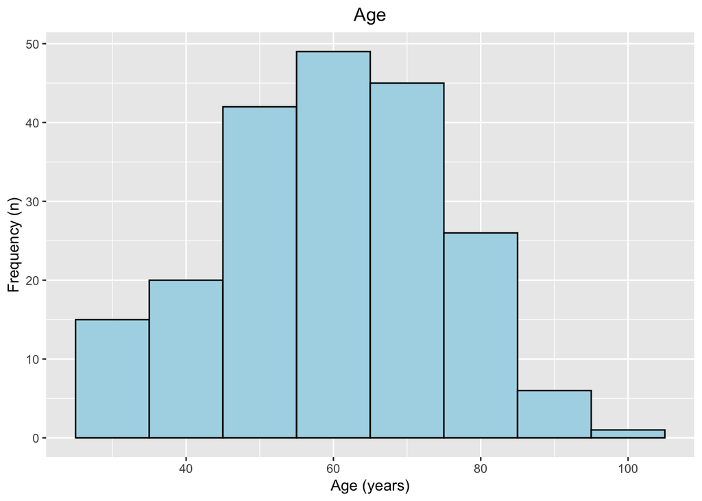

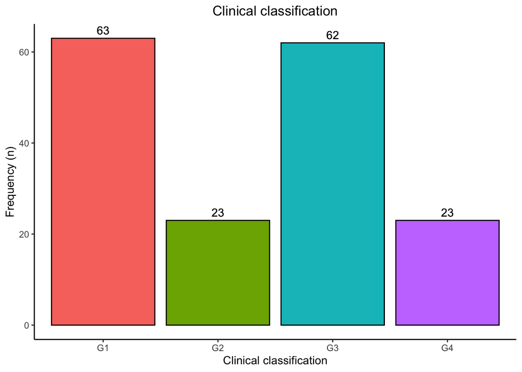

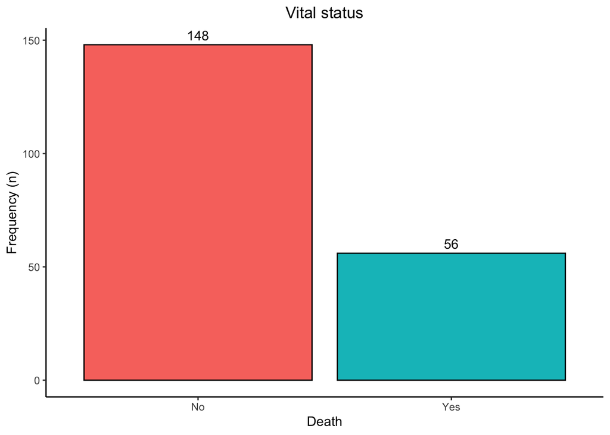

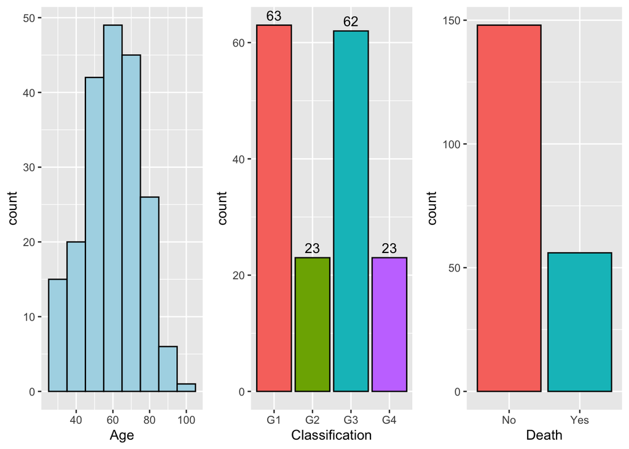

## Reproduce Figure 2 from the publication

but instead of representing the clusters in the annotation, represent the groups (G1 to G4)

```
##     ID   IL-6 CXCL10  IL-38   IL-8  IFN-ɑ  IL-10  TNF-ɑ   CCL2   CCL3  IFN-γ
##      0     32      6      6      6      6      6      6      6      6      6
##  IL-1β  G-CSF
##      6      6
```

```
##     ID   IL-6 CXCL10  IL-38   IL-8  IFN-ɑ  IL-10  TNF-ɑ   CCL2   CCL3  IFN-γ
##      0      0      0      0      0      0      0      0      0      0      0
##  IL-1β  G-CSF
##      0      0
```

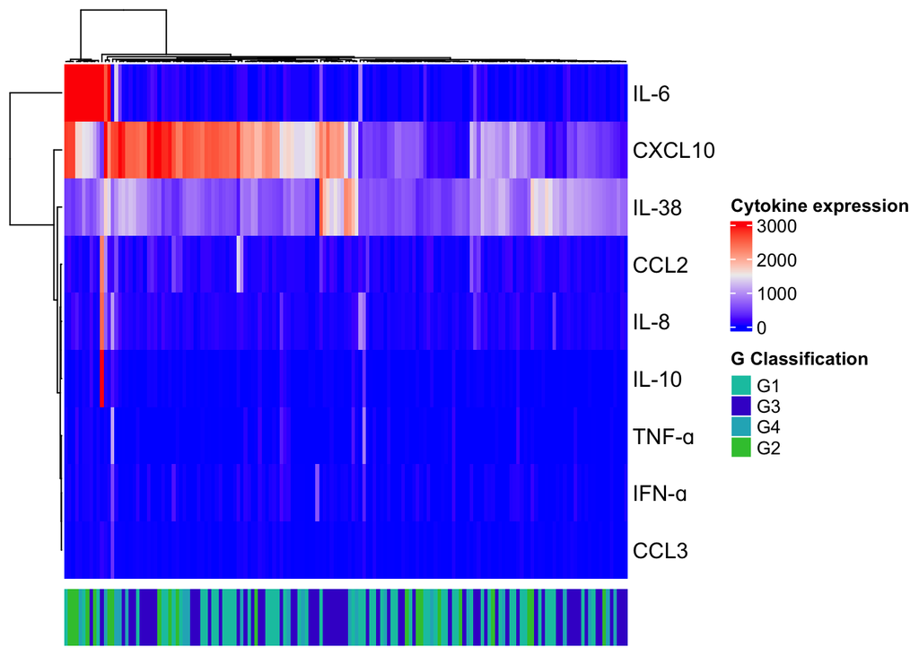

- As it can be seen from the annotation, clinical classification groups can’t be clustered base on the cytokine expression.

## Improve figure 2 of the publication

Add a second annotation with information of deathm and a third one with information of gender

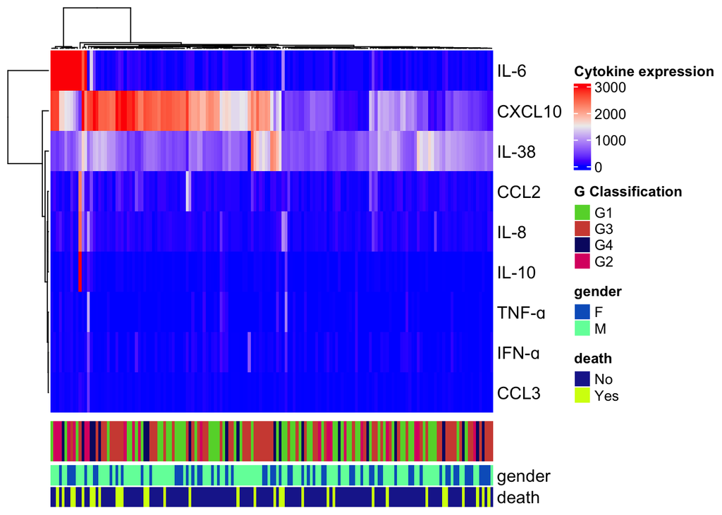

# session info

R version 4.2.2 (2022-10-31 ucrt) Platform: x86_64-w64-mingw32/x64 (64-bit) Running under: Windows 10 x64 (build 19045)

Matrix products: default

locale:  
[1] LC_COLLATE=Spanish_Spain.utf8 LC_CTYPE=Spanish_Spain.utf8 LC_MONETARY=Spanish_Spain.utf8 [4] LC_NUMERIC=C LC_TIME=Spanish_Spain.utf8

attached base packages:  
[1] grid stats graphics grDevices utils datasets methods base

other attached packages:  
[1] ComplexHeatmap_2.14.0 gridExtra_2.3 RColorBrewer_1.1-3 dplyr_1.1.0  
[5] readxl_1.4.1 ggplot2_3.4.0 DataExplorer_0.8.2

loaded via a namespace (and not attached):  
[1] shape_1.4.6 circlize_0.4.15 GetoptLong_1.0.5 tidyselect_1.2.0 xfun_0.36  
[6] reshape2_1.4.4 colorspace_2.1-0 vctrs_0.5.2 generics_0.1.3 stats4_4.2.2  
[11] htmltools_0.5.4 yaml_2.3.7 utf8_1.2.2 rlang_1.0.6 pillar_1.8.1  
[16] glue_1.6.2 withr_2.5.0 BiocGenerics_0.44.0 networkD3_0.4 matrixStats_0.63.0  
[21] foreach_1.5.2 lifecycle_1.0.3 plyr_1.8.8 stringr_1.5.0 munsell_0.5.0  
[26] gtable_0.3.1 cellranger_1.1.0 GlobalOptions_0.1.2 htmlwidgets_1.6.1 codetools_0.2-18  
[31] evaluate_0.20 labeling_0.4.2 knitr_1.42 IRanges_2.32.0 fastmap_1.1.0